## **Input: Region Information**

Completed on Tue Aug 29 16:39:43 2023 (Asia/Shanghai), with the runtime of 6 seconds.

> **An interactive table** for user-input genomic regions (n=832, being processed). The table includes three columns: 1st column `Input GR` for input genomic regions in the format of `chr:start-end` (the genome build `mm10`), 2nd column `Chromosome` for the chromosome, 3rd `Length` for the region length (bp).

| Input GR | Chromosome | Length |
| --- | --- | --- |
| chr20:4090134-4092134 | chr20 | 2001 |
| chr11:117973237-117975237 | chr11 | 2001 |
| chr1:212634309-212636309 | chr1 | 2001 |
| chr1:212635821-212637821 | chr1 | 2001 |
| chr17:36127082-36129082 | chr17 | 2001 |
| chr20:4081996-4083996 | chr20 | 2001 |
| chr17:36143118-36145118 | chr17 | 2001 |
| chr17:36132988-36134988 | chr17 | 2001 |
| chr1:212637708-212639708 | chr1 | 2001 |
| chr2:113097209-113099209 | chr2 | 2001 |

[output cut: 822 more lines]

## **Output: Linked Genes**

> **Linked Gene table** contains information on genes (n=922, linked from input genomic regions), including the column `GScores` (ranged from 1 to 10) that quantifies the degree to which genes are likely modulated by input genomic regions. Please refer to **`Evidence table`** for details on the linking evidence.

| Linked genes | GScores | Description |
| --- | --- | --- |
| 1600027J07Rik | 10 | RIKEN cDNA 1600027J07 gene |
| 1700007E05Rik | 10 | RIKEN cDNA 1700007E05 gene |
| 1700007J10Rik | 10 | RIKEN cDNA 1700007J10 gene |
| 1700012C14Rik | 10 | RIKEN cDNA 1700012C14 gene |
| 1700012D16Rik | 10 | RIKEN cDNA 1700012D16 gene |
| 1700012E03Rik | 10 | RIKEN cDNA 1700012E03 gene |
| 1700015O11Rik | 10 | RIKEN cDNA 1700015O11 gene |
| 1700016P03Rik | 10 | RIKEN cDNA 1700016P03 gene |
| 1700020L13Rik | 10 | RIKEN cDNA 1700020L13 gene |
| 1700027I24Rik | 10 | RIKEN cDNA 1700027I24 gene |

[output cut: 912 more lines]

> **Evidence table** displays information about the genomic regions (listed under the column `GR`) that overlap the input genomic regions (listed under the column `Input GR`). The overlapped regions are used to define linked genes (listed under the column `Linked genes`) based on the evidence provided (see the column `Evidence`). The column `Evidence` indicates the datasets used, such as `Proximity` for genomic regions in proximity, and the prefix `EP_` for enhancer-gene datasets.

| Input GR | GR | Linked genes | Evidence |
| --- | --- | --- | --- |
| chr8:103392788-103394788 | chr8:103392788-103394788 | 1600027J07Rik | Proximity_50000bp |
| chr16:31343977-31345977 | chr16:31343977-31345977 | 1700007E05Rik | Proximity_50000bp |
| chr16:31343977-31345977 | chr16:31343977-31345977 | 1700007E05Rik | Proximity_50000bp |
| chr16:31343977-31345977 | chr16:31343977-31345977 | 1700007E05Rik | Proximity_50000bp |
| chr16:31349413-31351413 | chr16:31349413-31351413 | 1700007E05Rik | Proximity_50000bp |
| chr16:31349413-31351413 | chr16:31349413-31351413 | 1700007E05Rik | Proximity_50000bp |
| chr16:31349413-31351413 | chr16:31349413-31351413 | 1700007E05Rik | Proximity_50000bp |
| chr16:31396407-31398407 | chr16:31394851-31396851 | 1700007E05Rik | Proximity_50000bp |
| chr16:31396407-31398407 | chr16:31394851-31396851 | 1700007E05Rik | Proximity_50000bp |
| chr16:31396407-31398407 | chr16:31394851-31396851 | 1700007E05Rik | Proximity_50000bp |

[output cut: 7892 more lines]

## **Output: Enriched Terms**

> **An interactive table** that displays enriched ontology terms based on 922 linked genes. Each enriched term (the columns `Ontology`, `Term ID` and `Term Name`) has the enrichment z-score (`Z-score`), the enrichment significance level (`FDR`), odds ratio (`Odds ratio`) and 95% confidence intervals (`95% CI`), the number (`Num`) and list (`Members`) of member genes that overlap with linked genes. The table is sorted by FDR ascendingly.

| Ontology | Term ID | Term Name | Z-score | FDR | Odds ratio | 95% CI | Num | Members |
| --- | --- | --- | --- | --- | --- | --- | --- | --- |
| Biological Process | GO:0019882 | antigen processing and presentation | 9.4 | 1.7e-07 | 7.37 | [4.28, 12.1] | 20 | Ap3b1, Arl8b, Gm7030, Gm8909, H2-Aa, H2-Ab1, H2-Bl, H2-Ea, H2-Eb1, H2-Eb2, H2-Ob, H2-T-ps, H2-T10, H2-T3, H60b, Psmb8, Psmb9, Raet1e, Tap1, Tap2 |
| Biological Process | GO:0048002 | antigen processing and presentation of peptide antigen | 9.52 | 3.7e-07 | 9.19 | [4.92, 16.2] | 16 | Gm7030, Gm8909, H2-Aa, H2-Ab1, H2-Bl, H2-Ea, H2-Eb1, H2-Eb2, H2-Ob, H2-T-ps, H2-T10, H2-T3, H60b, Raet1e, Tap1, Tap2 |
| Biological Process | GO:0019884 | antigen processing and presentation of exogenous antigen | 8.31 | 3.3e-05 | 9.26 | [4.45, 17.8] | 12 | Ap3b1, H2-Aa, H2-Ab1, H2-Bl, H2-Ea, H2-Eb1, H2-Eb2, H2-Ob, H2-T-ps, H2-T10, H2-T3, Tap2 |
| Biological Process | GO:0002483 | antigen processing and presentation of endogenous peptide antigen | 8.46 | 3.3e-05 | 10.4 | [4.79, 20.9] | 11 | Gm7030, Gm8909, H2-Bl, H2-Ea, H2-T-ps, H2-T10, H2-T3, H60b, Raet1e, Tap1, Tap2 |
| Biological Process | GO:0019883 | antigen processing and presentation of endogenous antigen | 8.15 | 4.2e-05 | 9.69 | [4.47, 19.3] | 11 | Gm7030, Gm8909, H2-Bl, H2-Ea, H2-T-ps, H2-T10, H2-T3, H60b, Raet1e, Tap1, Tap2 |
| Biological Process | GO:0002478 | antigen processing and presentation of exogenous peptide antigen | 8.15 | 4.2e-05 | 9.69 | [4.47, 19.3] | 11 | H2-Aa, H2-Ab1, H2-Bl, H2-Ea, H2-Eb1, H2-Eb2, H2-Ob, H2-T-ps, H2-T10, H2-T3, Tap2 |
| Biological Process | GO:0002503 | peptide antigen assembly with MHC class II protein complex | 10.1 | 7.1e-05 | 36.6 | [9.76, 138] | 6 | H2-Aa, H2-Ab1, H2-Ea, H2-Eb1, H2-Eb2, H2-Ob |
| Biological Process | GO:0002399 | MHC class II protein complex assembly | 10.1 | 7.1e-05 | 36.6 | [9.76, 138] | 6 | H2-Aa, H2-Ab1, H2-Ea, H2-Eb1, H2-Eb2, H2-Ob |
| Biological Process | GO:0033141 | positive regulation of peptidyl-serine phosphorylation of STAT protein | 8.48 | 0.00011 | 14.7 | [5.58, 35.1] | 8 | Ifna12, Ifna13, Ifna14, Ifna15, Ifna16, Ifna2, Ifna9, Ifnab |
| Biological Process | GO:0002475 | antigen processing and presentation via MHC class Ib | 7.49 | 0.00016 | 9 | [4, 18.4] | 10 | Ap3b1, Gm7030, Gm8909, H2-Bl, H2-T-ps, H2-T10, H2-T3, H60b, Raet1e, Tap2 |

[output cut: 1935 more lines]

## **Output: Dotplot**

> **A dotplot** of enriched ontology terms identified using Fisher’s exact test. An editable pdf file is also available for download.

DOWNLOAD .pdf

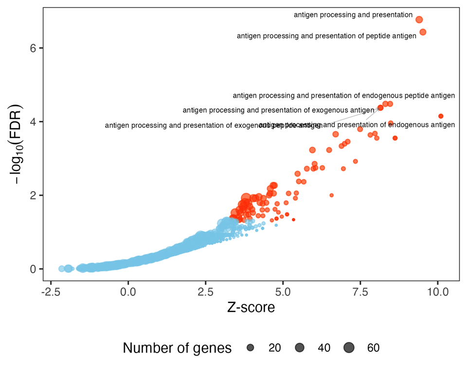

## **Output: Forest Plot**

> **A forest plot** of enriched ontology terms identified using Fisher’s exact test. An editable pdf file is also available for download.

DOWNLOAD .pdf

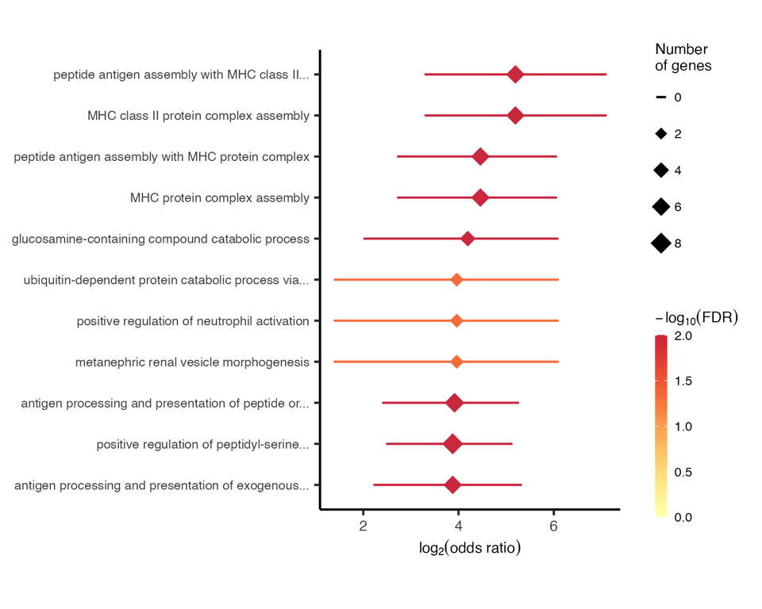

Figure 2: Forest plot for enriched ontology terms (ordered by odds ratio descendingly).